# LinearRegression-Moneyball

Sanyamc

Friday, April 17, 2015

# The Moneyball Story

This section is about the famous Moneyball story of A’s. How taking an analytical approach they were able to identify undervalued players.

Analysis suggested that some skills are undervalued and some skills are overvalued. A’s premise was that if they could detect undervalued skills using Analytics they could find players at a bargain.

Goal of the teams usually is to make to playoffs. Goal of A’s was to get to playoffs using Analytics.

So statistician at A’s came up that the team needs to score 135 runs more than they allow to win 95 games.

```r
baseball = read.csv('E:/github/Courses/Analytics-Edge/datasets/baseball.csv')
str(baseball)
```

```
## 'data.frame':    1232 obs. of  15 variables:
##  $ Team        : Factor w/ 39 levels "ANA","ARI","ATL",..: 2 3 4 5 7 8 9 10 11 12 ...
##  $ League      : Factor w/ 2 levels "AL","NL": 2 2 1 1 2 1 2 1 2 1 ...
##  $ Year        : int  2012 2012 2012 2012 2012 2012 2012 2012 2012 2012 ...
##  $ RS          : int  734 700 712 734 613 748 669 667 758 726 ...
##  $ RA          : int  688 600 705 806 759 676 588 845 890 670 ...
##  $ W           : int  81 94 93 69 61 85 97 68 64 88 ...
##  $ OBP         : num  0.328 0.32 0.311 0.315 0.302 0.318 0.315 0.324 0.33 0.335 ...
##  $ SLG         : num  0.418 0.389 0.417 0.415 0.378 0.422 0.411 0.381 0.436 0.422 ...
##  $ BA          : num  0.259 0.247 0.247 0.26 0.24 0.255 0.251 0.251 0.274 0.268 ...
##  $ Playoffs    : int  0 1 1 0 0 0 1 0 0 1 ...
##  $ RankSeason  : int  NA 4 5 NA NA NA 2 NA NA 6 ...
##  $ RankPlayoffs: int  NA 5 4 NA NA NA 4 NA NA 2 ...
##  $ G           : int  162 162 162 162 162 162 162 162 162 162 ...
##  $ OOBP        : num  0.317 0.306 0.315 0.331 0.335 0.319 0.305 0.336 0.357 0.314 ...
##  $ OSLG        : num  0.415 0.378 0.403 0.428 0.424 0.405 0.39 0.43 0.47 0.402 ...
```

```r
summary(baseball)
```

```
##       Team     League        Year            RS               RA
##  BAL    : 47   AL:616   Min.   :1962   Min.   : 463.0   Min.   : 472.0
##  BOS    : 47   NL:616   1st Qu.:1977   1st Qu.: 652.0   1st Qu.: 649.8
##  CHC    : 47            Median :1989   Median : 711.0   Median : 709.0
##  CHW    : 47            Mean   :1989   Mean   : 715.1   Mean   : 715.1
##  CIN    : 47            3rd Qu.:2002   3rd Qu.: 775.0   3rd Qu.: 774.2
##  CLE    : 47            Max.   :2012   Max.   :1009.0   Max.   :1103.0
##  (Other):950
##        W              OBP              SLG               BA
##  Min.   : 40.0   Min.   :0.2770   Min.   :0.3010   Min.   :0.2140
##  1st Qu.: 73.0   1st Qu.:0.3170   1st Qu.:0.3750   1st Qu.:0.2510
##  Median : 81.0   Median :0.3260   Median :0.3960   Median :0.2600
##  Mean   : 80.9   Mean   :0.3263   Mean   :0.3973   Mean   :0.2593
##  3rd Qu.: 89.0   3rd Qu.:0.3370   3rd Qu.:0.4210   3rd Qu.:0.2680
##  Max.   :116.0   Max.   :0.3730   Max.   :0.4910   Max.   :0.2940
##
##     Playoffs        RankSeason     RankPlayoffs         G
##  Min.   :0.0000   Min.   :1.000   Min.   :1.000   Min.   :158.0
##  1st Qu.:0.0000   1st Qu.:2.000   1st Qu.:2.000   1st Qu.:162.0
##  Median :0.0000   Median :3.000   Median :3.000   Median :162.0
##  Mean   :0.1981   Mean   :3.123   Mean   :2.717   Mean   :161.9
##  3rd Qu.:0.0000   3rd Qu.:4.000   3rd Qu.:4.000   3rd Qu.:162.0
##  Max.   :1.0000   Max.   :8.000   Max.   :5.000   Max.   :165.0
##                   NA's   :988     NA's   :988
##       OOBP             OSLG
##  Min.   :0.2940   Min.   :0.3460
##  1st Qu.:0.3210   1st Qu.:0.4010
##  Median :0.3310   Median :0.4190
##  Mean   :0.3323   Mean   :0.4197
##  3rd Qu.:0.3430   3rd Qu.:0.4380
##  Max.   :0.3840   Max.   :0.4990
##  NA's   :812      NA's   :812
```

So we wanna include data which was < 2002 to replicate the findings of moneyball. Lets also create a new column for Run deficit since we are going to use that to predict the wins.

Lets create a scatter plot to see if there is relationship between Run diff and Wins.

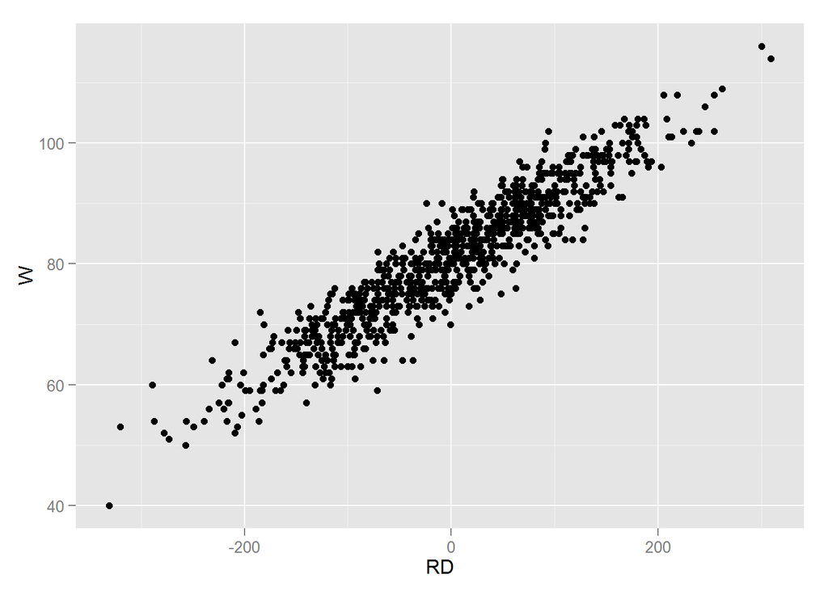

```r
moneyball = subset(baseball,baseball$Year<2002)
moneyball$RD = moneyball$RS-moneyball$RA
library('ggplot2')
ggplot(aes(x=RD,y=W),data=moneyball)+geom_point()
```

As evident from the plot above, there is a relationship between run difference and wins(As intuitively expected)

When we don’t know what variables to plot, we generally use a scatterplot matrix. Use ggally pkg.

Now lets create the model

```r
model1 <- lm(moneyball$W~moneyball$RD)
summary(model1)
```

```
##
## Call:
## lm(formula = moneyball$W ~ moneyball$RD)
##
## Residuals:
##      Min       1Q   Median       3Q      Max
## -14.2662  -2.6509   0.1234   2.9364  11.6570
##
## Coefficients:
##               Estimate Std. Error t value Pr(>|t|)
## (Intercept)  80.881375   0.131157  616.67   <2e-16 ***
## moneyball$RD  0.105766   0.001297   81.55   <2e-16 ***
## ---
## Signif. codes:  0 '***' 0.001 '**' 0.01 '*' 0.05 '.' 0.1 ' ' 1
##
## Residual standard error: 3.939 on 900 degrees of freedom
## Multiple R-squared:  0.8808, Adjusted R-squared:  0.8807
## F-statistic:  6651 on 1 and 900 DF,  p-value: < 2.2e-16
```

We have a very strong R2 above.

Now next point is how we score more runs and how do we reduce the runs given.

Well batting score could be predicted using On-base (how many times player gets the base) and Slugging Percentages(how far the ball is hit)

Diff between OBP and Batting Avg. is that OBP includes walking too.

Now lets see if we can use statistics to see which variables predicts the score by creating a lm.

```r
model2 <-lm(moneyball$RS~moneyball$BA+moneyball$OBP+moneyball$SLG)
model3<-lm(moneyball$RS~moneyball$OBP+moneyball$SLG,moneyball)

summary(model2)
```

```
##
## Call:
## lm(formula = moneyball$RS ~ moneyball$BA + moneyball$OBP + moneyball$SLG)
##
## Residuals:
##     Min      1Q  Median      3Q     Max
## -70.941 -17.247  -0.621  16.754  90.998
##
## Coefficients:
##               Estimate Std. Error t value Pr(>|t|)
## (Intercept)    -788.46      19.70 -40.029  < 2e-16 ***
## moneyball$BA   -368.97     130.58  -2.826  0.00482 **
## moneyball$OBP  2917.42     110.47  26.410  < 2e-16 ***
## moneyball$SLG  1637.93      45.99  35.612  < 2e-16 ***
## ---
## Signif. codes:  0 '***' 0.001 '**' 0.01 '*' 0.05 '.' 0.1 ' ' 1
##
## Residual standard error: 24.69 on 898 degrees of freedom
## Multiple R-squared:  0.9302, Adjusted R-squared:   0.93
## F-statistic:  3989 on 3 and 898 DF,  p-value: < 2.2e-16
```

```r
summary(model3)
```

```
##
## Call:
## lm(formula = moneyball$RS ~ moneyball$OBP + moneyball$SLG, data = moneyball)
##
## Residuals:
##     Min      1Q  Median      3Q     Max
## -70.838 -17.174  -1.108  16.770  90.036
##
## Coefficients:
##               Estimate Std. Error t value Pr(>|t|)
## (Intercept)    -804.63      18.92  -42.53   <2e-16 ***
## moneyball$OBP  2737.77      90.68   30.19   <2e-16 ***
## moneyball$SLG  1584.91      42.16   37.60   <2e-16 ***
## ---
## Signif. codes:  0 '***' 0.001 '**' 0.01 '*' 0.05 '.' 0.1 ' ' 1
##
## Residual standard error: 24.79 on 899 degrees of freedom
## Multiple R-squared:  0.9296, Adjusted R-squared:  0.9294
## F-statistic:  5934 on 2 and 899 DF,  p-value: < 2.2e-16
```

Now we can see that Batting average is overvalued while other more imp. variables are undervalued, like OBP and SLG

Similarly we can use the same approach to predict the number of run that is going to be scored in upcoming season based on team’s stats in previous season. For e.g.

Using a team’s OBP and SLG for a given year, we can predict the runs scored in next year.

Now why Billy Bean said that his technique will work untill the playoffs? Reason is that in the league games the number of games are large, hence the luck evens out and skill shines through. Lets see if data shows us that. If we look at the corelation between team winning in league and team winning the World Series turns out to be very low (0.03) suggesting that sample size in playoffs is small.

Lets take a look at 2012 and 2013 playoff teams and their season wins.

```r
teamRank =c(1,2,3,3,4,4,4,4,5,5)
win_2012=c(94,88,95,88,93,94,98,97,93,94)
win_2013=c(97,97,92,93,92,96,94,96,92,90)

cor(teamRank,win_2012)
```

```
## [1] 0.3477129
```

```r
cor(teamRank,win_2013)
```

```
## [1] -0.6556945
```

As one cor is +Ve and other is -ve, its hard to predict the playoff wins based on league wins for a team. We wouldn’t be comfortable predicting that.

Before Money ball became popular, the A’s were an outlier but now other teams are also using this techniques and getting more closer to A’s techniques.

Other than moneyball there is another book *“The extra 2%”* which depicts story of Tampa Bay rays.

As we can see that model above was really simple yet it led to better decisions than **gut feeling**. Now every major teams have stats group. Boston Red sox employed these techniques and won the world series after 86 years.

This technique is now a well know term known as **Sabermetrics**

While Moneyball made the use of analytics in sports very popular, baseball is not the only sport for which analytics is used. Analytics is currently used in almost every single sport, including basketball, soccer, cricket, and hockey.

*Basketball*: The study of analytics in basketball, called APBRmetrics, is very popular. There have been many books written in this area, including “Pro Basketball Forecast” by John Hollinger and “Basketball on Paper” by Dean Oliver. There are also several websites dedicated to the study of basketball analytics, including 82games.com. We’ll talk more about basketball during recitation.

*Soccer*: The soccer analytics community is currently growing, and new data is constantly being collected. Many argue that it is much harder to apply analytics to soccer, but there are several books and websites on the topic. Check out “The Numbers Game: Why Everything You Know about Football is Wrong” by Chris Anderson and David Sally, as well as the websites socceranalysts.com and soccermetrics.net.

*Cricket*: There are several websites dedicated to building models for evaluating player performance in cricket. Check out cricmetric.com and impactindexcricket.com.

*Hockey*: Analytics are used in hockey to track player performance and to better shape the composition of teams. Check out the websites hockeyanalytics.com and lighthousehockey.com.